# RNAseq data summary

Last Updated: 2021-07-26

## Overview

We have 39 RNAseq libraries from the following samples (start a summit session and use opt+cmd+return to send to terminal):

```bash
ls /scratch/summit/camcd@colostate.edu/felv_rnaseq/data/samples/
```

Samples are named such as: `4438_S1_L002_R1_001.fastq.gz` in the `data/raw` directory. L002 is common to all files and indicates sequencing lane. 001 is also common to all files and is just the standard Illumina append. S indicates sample. I could shorten all filenames in `data` like so:

```bash
for fname in *.fastq.gz ; do mv "$fname" "$(echo "$fname" | sed -r 's/L002_//')" ; done
for fname in *.fastq.gz ; do mv "$fname" "$(echo "$fname" | sed -r 's/_001//')" ; done
```

However, it’s best practice to **not** rename samples. For Snakemake, a better option is to hardlink to the files, rename with tidy sample names (e.g. S001), then use input functions and wildcards on these.

### The cat genome

The most recent cat genome assembly is: [Felis_catus_9.0](https://www.ncbi.nlm.nih.gov/assembly/GCF_000181335.3/), which has a total sequence length of 2.52 Gb and 19 chromosomes.

According to the [RefSeq Annotation Report](https://www.ncbi.nlm.nih.gov/genome/annotation_euk/Felis_catus/104/), it consists of:

- Genes/psuedogenes: 35,588 (or else 31,417???)
  - 19,748 protein-coding
- mRNAs: 54,713

## Pipeline

I’d like to start using Snakemake, as recommended by Eric Anderson. In the meantime, I’ll do the following pipeline with batch scripts:

1. run fastqc
2. run multiqc
3. trim
4. re-run fastqc on trimmed libraries
5. re-run multiqc on trimmed libraries
6. run STAR in quantmode
7. run OrthoFinder to restrict to cat/puma orthologs
8. restrict to genes that fall within 1Mb of LTR integration sites
9. edgeR
10. WGCNA

### fastqc + multiqc

Because fastqc assigns 250MB per cpu and I want to try using 19 cores, I requested 5GB (250 x 19 = 4750).

I submitted the fastqc.sh script via:

```bash
sbatch workflow/scripts/fastqc.sh
```

With the `--test-only` flag first to make sure I wasn’t requesting more memory than existed. This took ~2.5 hours to run. This could definitely be better optimized as a job array…

### Trimgalore

Trimgalore worked great as a loop with standard quality and read length flags. See trimgalore_test.sh.

### STAR (`quantMode`)

Ran STAR in `quantMode`, which generates gene-level quantification files. starquant_test.sh.

I then just used bash one-liners to compile the **unstranded** output into a counts matrix:

```bash
ls *ReadsPerGene.out.tab | paste -s - > samplenames.txt

for i in *ReadsPerGene.out.tab; do awk '{print $2}' $i > $i.unstranded; done

cat samplenames.txt unstranded_counts.txt > unstranded_counts_matrix.txt

awk '{print $1}' X2654PLUS_S14_L002_ReadsPerGene.out.tab | paste - unstranded_counts_matrix.txt > readcountsmatrix.txt
```

**Note:** I don’t know if Elliott used a stranded library prep, so just using unstranded counts data at the moment.

### OrthoFinder (RBH analysis)

If we want to compare gene expression between our cat and panther samples, we need to restrict analysis to only orthologs. There are a number of ways to do this. Classically, we do it with a reciprocal best hit `blastp` run (blast all cat samples to puma genome, blast all puma samples to cat genome, retain only genes with hits both ways as presumptive orthologs). There are now many programs that will do this for you that are much faster than a local blast alignment. One is OrthoFinder, which uses `diamond`.

OrthoFinder requires protein fasta files for each proteome of interest, then performs an all-vs-all blast with `diamond`. An added bonus is that it also uses gene trees to infer orthology, which is more rigorous than some other approaches.

I’m following this [tutorial](https://davidemms.github.io/orthofinder_tutorials/running-an-example-orthofinder-analysis.html).

1. download the proteomes (see config file) and unzip
2. get only primary transcript using OrthoFinder python script: `for f in *.faa ; do python primary_transcript.py $f ; done`
3. run OrthoFinder: `orthofinder -f primary_transcripts/`

OrthoFinder creates a results dir called ‘OrthoFinder’ inside the input proteome directory. For the RBH, we basically only care about Orthologues output.

**Troubleshooting:** For some reason, the standard tutorial code isn’t working. The ortholog file, which should have three columns (orthogroup, plus one column of cat proteins, one column of puma proteins) has puma protein identifiers in *both* the cat and puma column…

I’m trying to re-run it after cleaning the fastas generated after running the `primary_transcript.py` script. The tutorial cleaned fastas just have the protein identifier, then the sequence. Mine had the protein identifier, then the protein name, then the species in brackets. The following sed removes everything after the protein identifier.

```bash
sed 's/\s.*$//' GCF_000181335.3_Felis_catus_9.0_protein.faa > GCF_000181335.3_Felis_catus_9.0_protein.cleaned.faa

sed 's/\s.*$//' GCF_003327715.1_PumCon1.0_protein.faa > GCF_003327715.1_PumCon1.0_protein.cleaned.faa
```

From here, I’m re-running orthofinder_test.sh

…Annnnd that didn’t work. I don’t understand why it’s messing up the names! Try renaming the fasta files??? There’s no way that will change anything…

It looks like the tutorial dataset uses BLAST instead of Diamond. Maybe that’s somehow having an effect??

Actually…I’m dumb it is working…it’s just that some of the felis refseq ids start with XP, while all of the puma ids do, so I thought it was assigning puma ids to felis ugggghhh.

Other methods of QC are to look at the gene trees and the gene duplication events to make sure they make sense…because we only have two species, I don’t think the trees are really going to show anything useful.

**Ortholog file:** Since most of our samples are cats and we only have one panther, it makes more sense to use the cat ortholog file than the panther ortholog file.

Once this is finished, I’ll filter the respective read counts matrices to only orthologs, and combine for DGE analysis.

The ortholog file lists protein IDs, and I need to convert to gene IDs:

There are multiple proteins derived from each gene.

```r
dat <- read_delim("readcountsmatrix.txt", delim = "\t") %>% select(-DC2Pool, -DC3Pool)
counts <- dat[-c(1:4, 31498),]

counts_w_protein <- left_join(ortho_and_gene, counts, by=c("gene_id"="genes"))

counts_ortho_only <- counts_w_protein %>%
  #select(-Cat_protein_id, -transcript_id) %>%
  distinct() %>%
  drop_na()
write_delim(counts_ortho_only, "results/orthofinder/genecounts_orthologs.txt", delim="\t")
```

### ID genes 1 Mb up and downstream of LTR integration sites

After restricting to orthologs, we can further restrict our gene set to only those genes that are within 1 Mb of the ~700 LTR integration sites that Elliott identified.

Using Supplemental Table 1 from Elliott’s integration site manuscript, I extracted LTR start sites, then generated a list of chromosomal regions +/- 1 Mb.

I used this list of defined regions (which is in bed format) to query the [UCSC Table Browser](http://genome.ucsc.edu/cgi-bin/hgTables) to extract all genes within these windows.

```r
LTR_genes <- read_delim("data/felCat9_1Mb_LTRsites.txt", delim="\t", skip = 1, col_names = F) %>%
  select(X4) %>%
  distinct()

LTR_genes %>% summarise(n())
```

| n() |
| --- |
| 31076 |

Based on the genes extracted from UCSC, it appears there are 31,076 genes within 1 Mb of an LTR integration site. This is essentially the entire genome! Thus, it’s not going to give us any more specific results than we already have. Options for parsing this out better:

1. Restrict to <1 Mb up and downstream.
   - The 1 Mb decision was because this is the maximum distance for LTR enhancer function. We could instead look just at promoter function? What would this distance be?
2. Pick out particularly interesting integration sites and look only at those.
   - For example, only the integration sites found in >10 cats

**I’ll use this second approach**

#### Interesting integration sites

**1. Fibroblasts: infected vs. uninfected** Restrict to LTR sites present in ≥3 (out of 4) fibroblast samples = 78 LTR sites

**2. PMBCs: present vs absent** Restrict to LTR sites present in 3 (out of 6) PMBC samples = 42 sites

**3. Present in ≥10 cats** Restrict to sites only found in ≥10 cats in Elliott’s larger study = 87 sites

### edgeR

I used the readcountsmatrix.txt and the sample metadata to begin edgeR analyses.

#### Data exploration

Code: DGE_dataexplore.R

Looking at all samples, we can see that there are 31,498 genes in the full dataset. After modest filtering for sequence errors, that goes down to ~16,000 genes. Library size ranged from 2,692,910 (MischiefPlus) to 33,912,615 (DC4PLUS).

```
## [1] 16869    15
```

```
## [1] 13176    15
```

|  | group | lib.size | norm.factors |
| --- | --- | --- | --- |
| 4438 | PBMC_uninfected | 17919458 | 1.0263962 |
| 4460 | PBMC_uninfected | 16672265 | 0.9886926 |
| 4474 | PBMC_uninfected | 17945278 | 0.9632811 |
| 4501 | PBMC_uninfected | 10816428 | 0.9356852 |
| 4510 | PBMC_uninfected | 4381299 | 1.0528431 |
| 4520 | PBMC_uninfected | 13836060 | 0.9210577 |
| DC1MINUS | fibroblast_uninfected | 20155038 | 0.8307344 |
| DC2MINUES | fibroblast_uninfected | 22218736 | 0.8369346 |
| DC2PLUS | fibroblast_infected | 18667882 | 0.8488244 |
| DC4MINUS | fibroblast_uninfected | 23792951 | 0.8179218 |

[output cut: 5 more lines]

That’s way too few reads for the Mischief (puma) samples. When we look at sample correlation and a PCA, we can also see that they’re way different from the other fibroblast samples, which is probably a function of poor sequencing, and is not biologically relevant? This remains true when we filter our counts matrix to only cat genes that have puma orthologs. Consider removing the Mischief samples from further analyses.

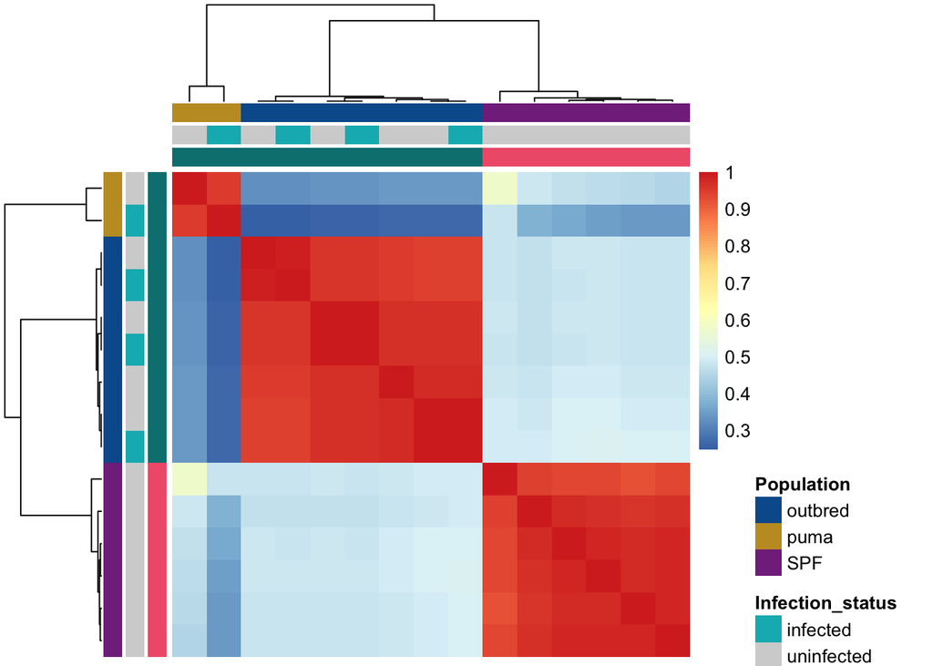

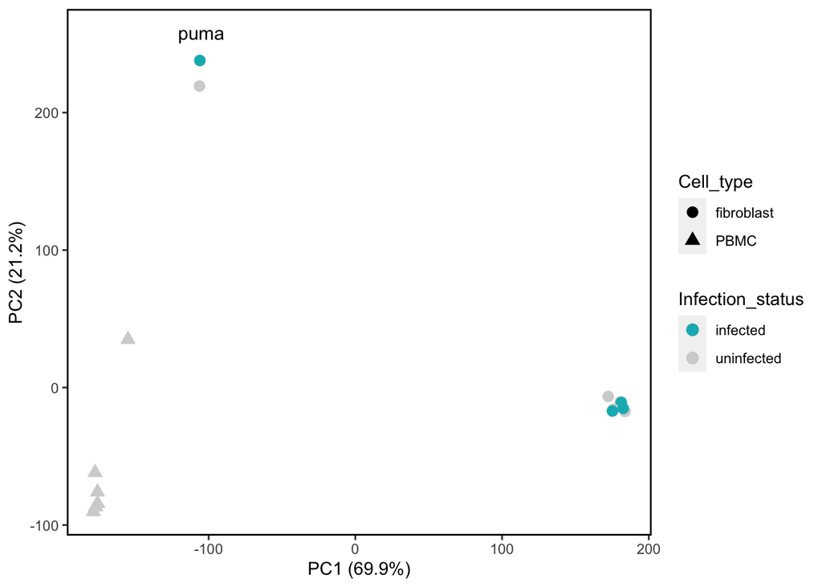

#### Differential expression

Code: DGE_edgeR.R

So there are a couple comparisons we can make:

- Cell type differential expression (PMBCs vs fibroblasts)
- uninfected vs. FeLV-infected differential expression (fibroblasts only)

Looking at cell type, 4510 is a big outlier, again I suspect due to poor sequencing, although Elliott says this animal has far more LTR sites than any of the other samples.

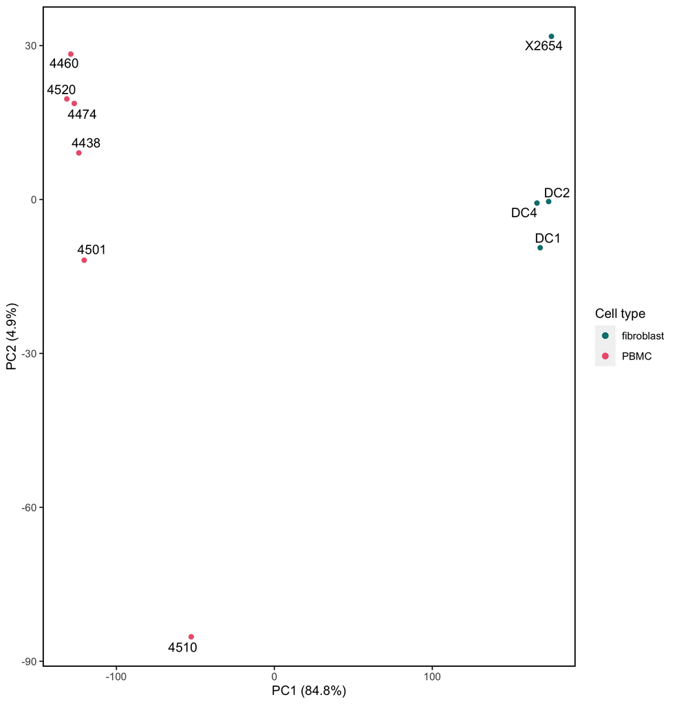

Expression is clearly cell-specific, which we would expect. There are ~6,000 genes significantly differentially expressed between fibroblasts and PMBCs.

Looking at FeLV infection status, we see that infection status plays a pretty negligible role:

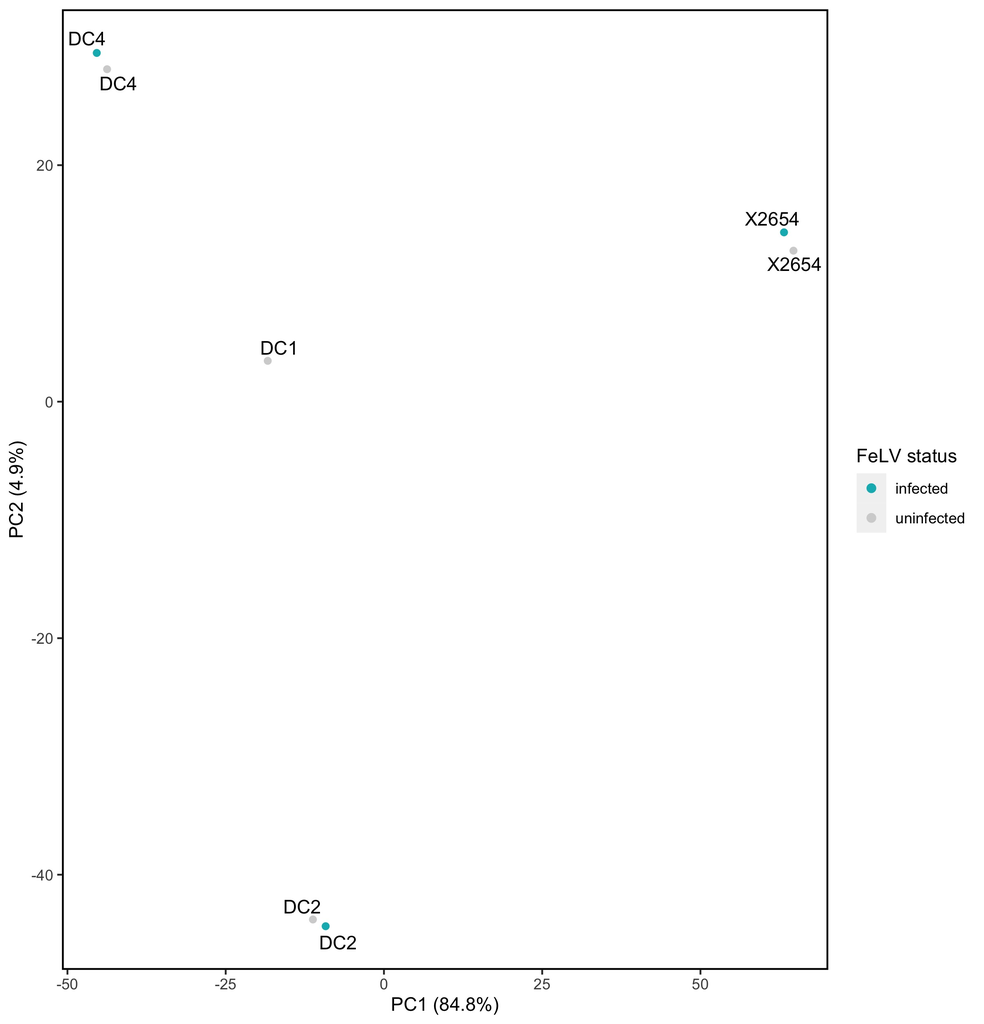

Samples cluster according to biological replicate and not according to infection status. Thus, we end up with only 3 significantly DE genes, all of which are uncharacterized proteins.